# 122140189_ho1

```python
import numpy as np
import matplotlib.pyplot as plt

# Membuat Array T (waktu) dari 0 sampai 2 dengan langkah sebesar 0.0001
T = np.arange(0, 2, 0.0001)

# Perhitungan Sinyal
y1 = 2 * np.sin(2 * np.pi * 3 * T + 0)
y2 = 1 * np.cos(2 * np.pi * 4 * T + (np.pi/4))
y3 = -1 * np.sin(2 * np.pi * 5 * T + (np.pi/2))
y4 = 0.5 * np.cos(2 * np.pi * 6 * T + np.pi)
```

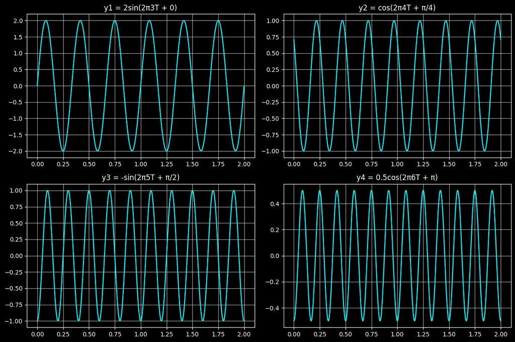

```python
# Membuat subplot 2x2
fig, axes = plt.subplots(2, 2, figsize=(12, 8))

# Plot tiap sinyal
axes[0, 0].plot(T, y1)
axes[0, 0].set_title("y1 = 2sin(2π3T + 0)")
axes[0, 0].grid()

axes[0, 1].plot(T, y2)
axes[0, 1].set_title("y2 = cos(2π4T + π/4)")
axes[0, 1].grid()

axes[1, 0].plot(T, y3)
axes[1, 0].set_title("y3 = -sin(2π5T + π/2)")
axes[1, 0].grid()

axes[1, 1].plot(T, y4)
axes[1, 1].set_title("y4 = 0.5cos(2π6T + π)")
axes[1, 1].grid()

# Set background color for all subplots
for ax in axes.flat:
    ax.set_facecolor('black')
    ax.grid(color='white', linestyle='-', linewidth=0.5)
    ax.spines['bottom'].set_color('white')
    ax.spines['top'].set_color('white')
    ax.spines['left'].set_color('white')
    ax.spines['right'].set_color('white')
    ax.tick_params(axis='both', colors='white')
    ax.title.set_color('white')

# Replot with cyan color
axes[0, 0].plot(T, y1, color='cyan')
axes[0, 1].plot(T, y2, color='cyan')
axes[1, 0].plot(T, y3, color='cyan')
axes[1, 1].plot(T, y4, color='cyan')

# Set figure background color
fig.patch.set_facecolor('black')

# Adjust layout and display
plt.tight_layout()
plt.show()
```

3. Pertanyaan Analisis

A. Berapa amplitudo dan frekuensi masing-masing sinyal?

B. Bagaimana pergeseran fase mempengaruhi posisi gelombang (Anda dapat mengubah nilai fase pada sinyal-sinyal yang telah dibuat sesuka anda)

C. Bandingkan sinyal-sinyal dengan amplitudo yang berbeda dan Diskusikan bagaimana amplitudo mempengaruhi tampilan gelombang

D. Bandingkan sinyal-sinyal dengan pergeseran fase yang berbeda dan Diskusikan bagaimana pergeseran fase mempengaruhi tampilan gelombang

### 3A. Amplitudo dan Frekuensi pada Masing-Masing Sinyal

#### Sinyal Y1:

- amplitudo = 2
- frekuensi = 3 Hz

#### Sinyal Y2:

- amplitudo = 1
- frekuensi = 4 Hz

#### Sinyal Y3:

- amplitudo = 1
- frekuensi = 5 Hz

#### Sinyal Y4:

- amplitudo = 0.5
- frekuensi = 6 Hz

### 3B. Pengaruh Pergeseran Fase pada Posisi Gelombang

Pergeseran fase pada posisi gelombang dipengaruhi oleh angka atau hitungan π(pi) yang ditambahkan setelah perhitungan frekuensi sehingga pergeseran fase tersebut mempengaruhi posisi gelombang seperti pada sinyal Y1 pergeseran fasenya 0 sehingga start gelombangnya berada di garis ekuibrilium ($0^\circ$), sinyal Y2 pergeseran fasenya sebanyak π/4 atau $45^\circ$, sinyal Y3 pergeseran fasenya sebanyak π/2 atau $90^\circ$, dan sinyal Y4 dengan pergeseran fase sebanyak π atau $180^\circ$

### 3C. Bandingkan sinyal-sinyal dengan amplitudo yang berbeda dan diskusikan bagaimana amplitudo mempengaruhi tampilan gelombang

Amplitudo yang berbeda-beda pada keempat sinyal tersebut mempengaruhi tinggi sinyal seperti:

- Pada sinyal Y1, amplitudonya atau tinggi sinyalnya berada di tinggi kedua,
- sedangkan pada sinyal Y2 dan Y3 tinggi sinyalnya berada di ketinggian 1 meski perbedaanya berada di positif dan negatif amplitudonya sehingga start gelombang Y2 ada di amplitudo positif dan Y3 ada di amplitudo negatif,
- dan pada sinyal Y4 tinggi sinyalnya berada di ketinggian 0,5.

### 3D. Bandingkan sinyal-sinyal dengan pergeseran fase yang berbeda dan diskusikan bagaimana pergeseran fase mempengaruhi tampilan gelombang

Setiap sinyal memiliki pergeseran fase yang berbeda-beda dan itu semua mempengaruhi tampilan titik gelombangnya.

- Pada sinyal Y1 dimana pergeseran fase gelombangnya sin($0^\circ$) sehingga titik awal gelombang berada di ketinggan amplitudo 0 atau di garis ekuibrilium.
- Pada sinyal Y2 pergeserannya π/4 atau cos($45^\circ$) dari amplitudo 1 sehingga titik awal gelombang berada di ketinggian amplitudo mendekati 0,75.
- Pada sinyal Y3 pergeseran fasenya π/2 atau -sin($90^\circ$) dari amplitudo 1 sehingga titik awal gelombang berada di ketinggian -1
- Pada sinyal Y4 pergeseran fasenya π atau cos($180^\circ$) dari amplitudo 0.5 sehingga titik awal gelombang berada di ketinggian mendekati antara -0,5 dan -0,4.

Sumber referensi pembelajaran fase gelombang (https://www.youtube.com/watch?v=L9rGgt-IMaQ)

4. **Tugas Lanjutan**:
   - Buat sinyal baru $y5$ yang merupakan kombinasi dari $y1$ dan $y2$ yaitu, $y5 = y1 + y2$.
   - Plot $y5$ dan diskusikan bagaimana kombinasi dua gelombang sinus/cosinus mempengaruhi bentuk gelombang yang dihasilkan.

Sekarang saya tampilkan plot sinyal Y5 dengan bantuan koding copilot model Claude 3.5 Sonnet, berikut tampilan plotnya:

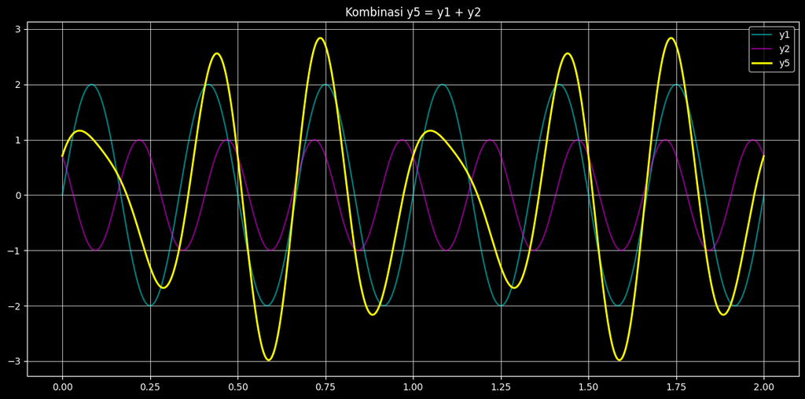

```python
# Create y5 as combination of y1 and y2
y5 = y1 + y2

# Create a new figure
plt.figure(figsize=(12, 6))

# Plot y1, y2, and y5
plt.plot(T, y1, color='cyan', label='y1', alpha=0.5)
plt.plot(T, y2, color='magenta', label='y2', alpha=0.5)
plt.plot(T, y5, color='yellow', label='y5', linewidth=2)
plt.title('Kombinasi y5 = y1 + y2', color='white')
plt.grid(True, color='white', linestyle='-', linewidth=0.5)
plt.legend(facecolor='black', labelcolor='white')

# Set background color
plt.gca().set_facecolor('black')
plt.gcf().patch.set_facecolor('black')

# Set axis colors
plt.gca().spines['bottom'].set_color('white')
plt.gca().spines['top'].set_color('white')
plt.gca().spines['left'].set_color('white')
plt.gca().spines['right'].set_color('white')
plt.gca().tick_params(axis='both', colors='white')

plt.tight_layout()
plt.show()
```